# Sample Midterm for POL200

Tony Hui (huitony.com)

October 19, 2016

This midterm uses [OkCupid](https://www.okcupid.com/) (“the best free dating site on Earth”) profiles: an anonomyzed dump of ~50,000 dating profiles (https://github.com/rudeboybert/JSE_OkCupid). Tony has further processed this down to ~6000 records to reduce information overload.

*The dataset is here: `http://huitony.com/pol201/profiles.csv`*

Some things about the test (don’t ignore):

- This test heavily emphasizes plotting (because in the real world, a picture is worth a thousand words). Therefore, it’s probably more useful as a preparation for the lab exam rather than the computer-less written exam.
- This test doesn’t emphasize probabilities (mostly because I suck at it, and because in the real world, probabilities are much, much more advanced than what you know). Please find other material to review on your own.
- Many questions in this exam are basically the same question, except just plotting a different variable. Feel free to skip around.

Some things about the data (feel free to ignore):

- Random noise was added to income (it was previously categorical)
- Incomes above 100k were set as 100k since the crazy earners make everything look bad
- M.D., Law, Masters, and PhD programs are considered “post-graduate”
- Many other nuances that makes this dataset more appropriate for an intro to data science class
- These profiles are all from California

**Most importantly, have fun!** Data Science is exciting, and I hope that you will find exploratory data analysis to be a whole lotta fun when going through this dataset.

```r
y <- read.csv("http://huitony.com/pol201/profiles.csv")
```

## Exploring the human body

- **Make a plot showing how many men and woman (`sex` column) there are in this dataset**

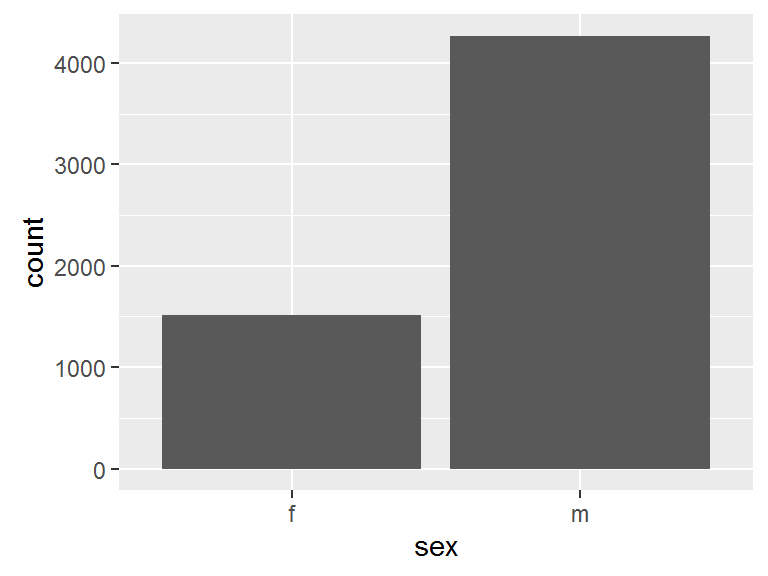

```r
ggplot(y, aes(sex)) +
  geom_bar()
```

- **Is it likely that this dataset is unbiased with respect to sex? Prove it with a probability** (hint: calculate the binomial probability of sampling `x` females given that the probability of sampling a female is `0.5`)

```r
table(y$sex)
```

```
##
##    f    m
## 1511 4268
```

```r
# two possible answers
dbinom(1511, size = 1511+4268, prob = 0.5)
```

```
## [1] 3.199274e-300
```

```r
pbinom(1511, size = 1511+4268, prob = 0.5)
```

```
## [1] 4.950702e-300
```

- **Make a stacked barplot of the conditional proportions that shows the relationship between `sex` and `ethnicity`. Is there bias with respect to ethnicity?**

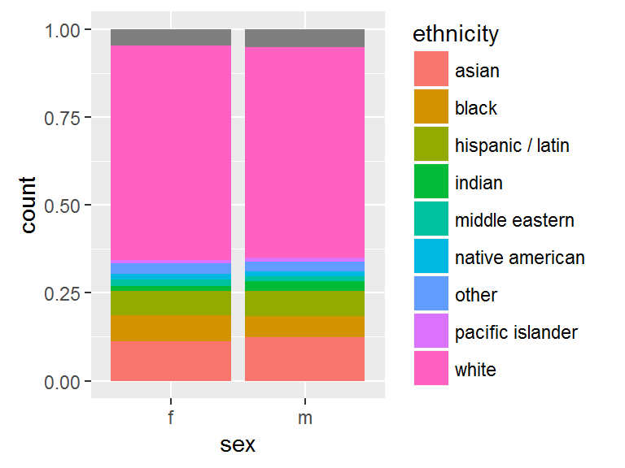

```r
ggplot(y, aes(sex, fill=ethnicity)) +
  geom_bar(position = "fill")
```

- **Make a conditional proportions table of `sex` and `body_type`. Be sure to add the margins to the table, that is, the totals.**

```r
addmargins(prop.table(table(y$sex, y$body_type)))
```

```
##
##       a little extra    athletic     average       curvy         fit
##   f      0.012285863 0.028551653 0.069043087 0.064370998 0.053469458
##   m      0.051219934 0.231181865 0.213877834 0.003979927 0.189652189
##   Sum    0.063505797 0.259733518 0.282920921 0.068350926 0.243121647
##
##              thin         Sum
##   f   0.033742862 0.261463921
##   m   0.048624329 0.738536079
##   Sum 0.082367192 1.000000000
```

- **Make a stacked barplot of the conditional proportions that shows the relationship between `sex` and `body_type`**

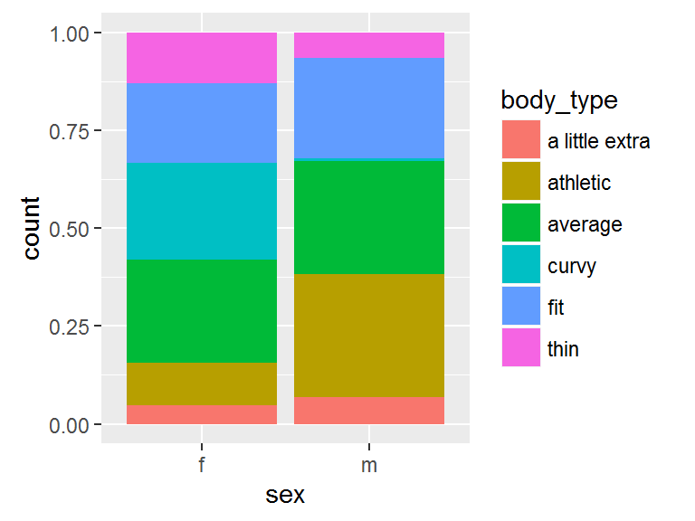

```r
ggplot(y, aes(sex, fill=body_type)) +
  geom_bar(position = "fill")
```

- **Which `body_type` has the biggest difference in proportions between male and female?**

```r
"curvy and athletic"
```

```
## [1] "curvy and athletic"
```

- **Make a histogram of people’s `height`. What is the mean and 95% confidence interval??**

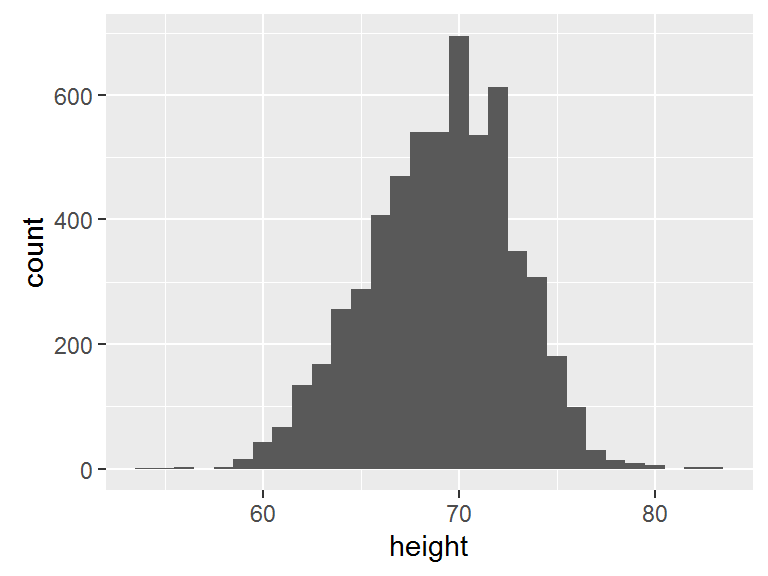

```r
ggplot(y, aes(height)) +
  geom_histogram()
```

```r
(mean=mean(y$height))
```

```
## [1] 69.11092
```

```r
sd=sd(y$height)
mean-sd*2
```

```
## [1] 61.73589
```

```r
mean+sd*2
```

```
## [1] 76.48595
```

- **I’m 6 feet (72 inches). Would you say I am abnormal?**

```r
"Nope, I'm well within the 95% confidence interval"
```

```
## [1] "Nope, I'm well within the 95% confidence interval"
```

- **Who’s taller (`height`)? Males or females? Make a boxplot to prove this**

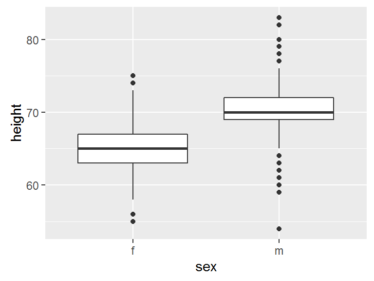

```r
ggplot(y, aes(sex, height)) +
  geom_boxplot()
```

- **Make a histogram of people’s `age`. Is this a normal distribution? Does this distribution make sense?**

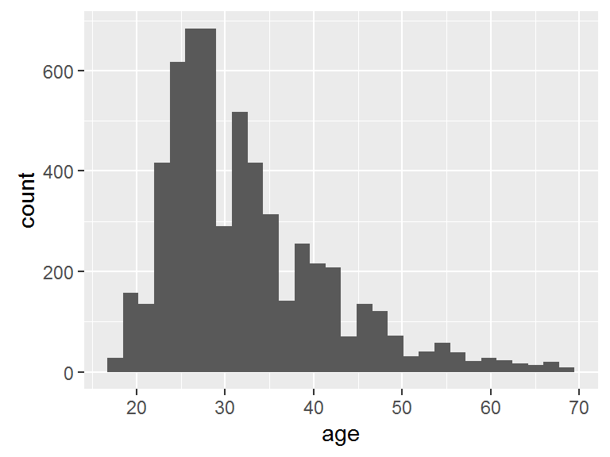

```r
ggplot(y, aes(age)) +
  geom_histogram()
```

- **Who’s older (`age`)? Males or females?**

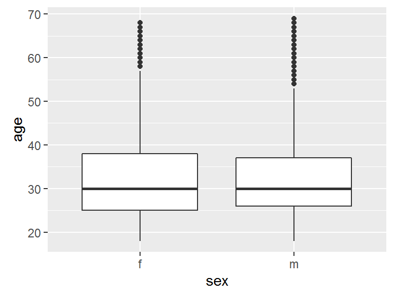

```r
ggplot(y, aes(sex, age)) +
  geom_boxplot()
```

- **Make a scatterplot comparing `age` vs `height` and show the line of best fit.**

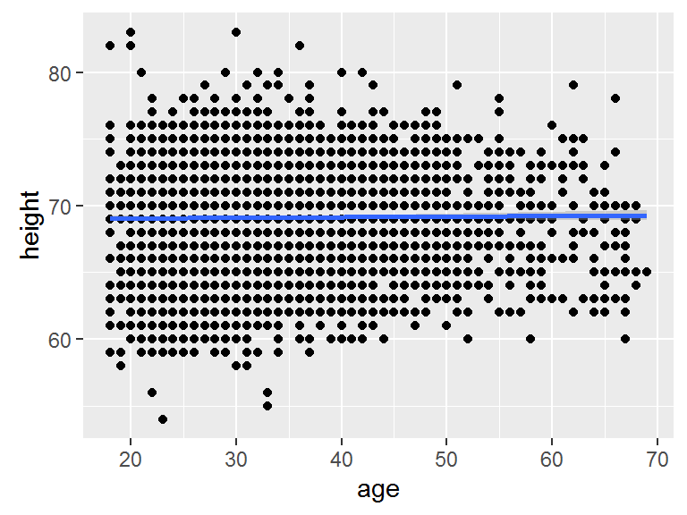

```r
ggplot(y, aes(age, height)) +
  geom_point() +
  geom_smooth(method="lm")
```

- **What is the correlation coefficient between `age` and `height`? Is this expected?**

```r
cor(y$age, y$height)
```

```
## [1] 0.01113226
```